# color and dominance: preliminary results

Rafael Maia

10/13/2017

```r
require(pavo)
require(dplyr)
require(phytools)
require(geiger)
require(phylolm)
require(MuMIn)
require(ggplot2)
require(viridis)
```

## Abbreviated methods

- Combined the data from Dale, Dunn, and myself
- Ran through a visual model assuming the average UV visual system and blue tit double cone
- Calculated $\Delta$S assuming a Weber fraction of 0.1 and receptor relative densities of 1:2:2:4
- Converted to Cartesian coordinates where Euclidean distances are in JND units
- considering only **male** color. In a few species, the sex of the only individual sampled was unknown; since these were monochromatic species I considered them males for the analyses.

### Caveats

- Not everyone measured all the same body parts. I think most of them are standard, but some species have more or less body parts measured
- samples per species per plumage patch ranged from 1 to 5
- individuals measured per species varied a lot too

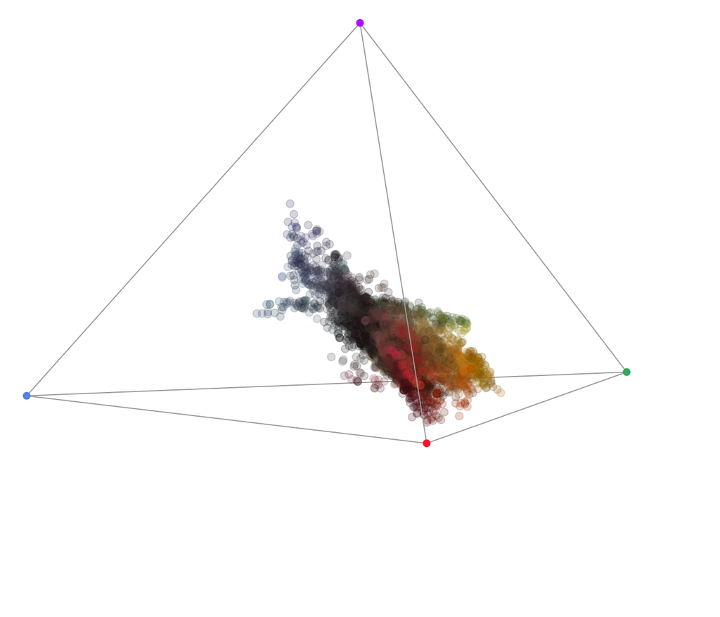

```r
load('output/processedata.rdata')
plot(colspace(visdat), col=spec2rgb(alldatp, alpha=0.2))
```

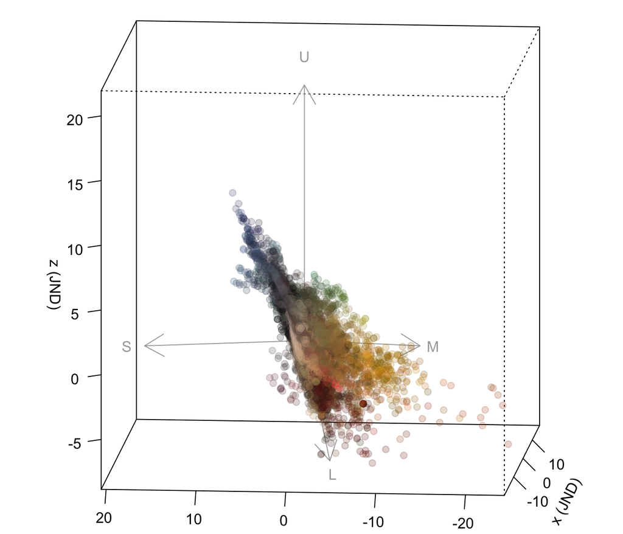

```r
plot(xyzdatr, col=spec2rgb(alldatp, alpha=0.2), theta=275, arrow.p=3.5)
```

### Variables used

- **Mean chromaticity** (“chrom”): distance of colors from the achromatic center, averaged across all patches for each species. Higher values indicate plumage is on average more “colorful” or saturated. (modified from Enlder & Mielke, calculated in noise-corrected Cartesian space, and thus in JND)
- **Chromatic heterogeneity** (“span”): average Euclidean distance between plumage patches of a species. Higher values indicate plumage composed of many different colors, low values indicate same or similar color accross plumage patches (in JND).
- **Mean brightness** (“achromean”): excitation of the double cone averaged across all patches for each species (in JND).
- **Brightness heterogeneity** (“achrospan”): average Euclidean distance between plumage patches of a species calculated from the double cone excitation (in JND).
- **Body mass** (“log.mass”): log-transformed body mass.
- **Dominance** (“bradley.terry.score.x”): the Bradley-Terry Dominance score (See Miller et al. 2017)

### The model

- The Jetz et al. phylogeny was used for comparative analyses, with an Ornstein-Uhlenbeck model for the phylogenetic covariance since phylogenetic signal in the residuals was low.
- A model-selection procedure was conducted starting with the following conditions:
  - the full model considered included body mass and the color variables (*log.mass + chrom + span + achromean + achrospan*)
  - only pairwise interactions between color variables and body mass were included (*log.mass:chrom + log.mass:span + log.mass:achromean+ log.mass:achrospan*)
  - only models considering chromatic **OR** achromatic color variables were considered. Thus, models that included, for example, *chrom + achromean*, were excluded.

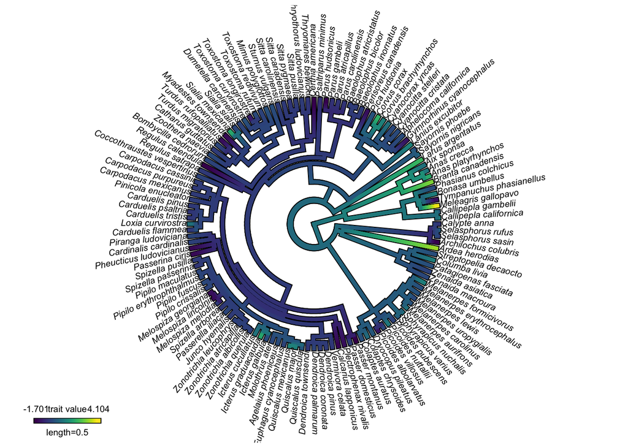

Phylogeny showing the scaled Dominance index

## Results

The best model included body mass, chromaticity, and their interaction. Marginal effects of chromaticity were not significant, though. The best model without chromaticity or their interaction had a $\Delta$AIC of 6.91.

```r
fullmodel <- phylolm(bradley.terry.score.x~log.mass + chrom + span + achromean + achrospan +
  log.mass:chrom +
  log.mass:span +
  log.mass:achromean +
  log.mass:achrospan, data=dat, phy=tr, model='OUrandomRoot')

#aictable <- dredge(fullmodel)
aictable <- dredge(fullmodel,
  subset=!(chrom && achromean) && !(chrom && achrospan) &&
         !(span && achromean) && !(span && achrospan))
```

```
## Fixed term is "(Intercept)"
```

```r
subset(aictable, delta < 10)
```

```
## Global model call: phylolm(formula = bradley.terry.score.x ~ log.mass + chrom +
##     span + achromean + achrospan + log.mass:chrom + log.mass:span +
##     log.mass:achromean + log.mass:achrospan, data = dat, phy = tr,
##     model = "OUrandomRoot")
## ---
## Model selection table
##        (Int)     achrm    achrs      chr log.mss       spn chr:log.mss
## 141 -0.09407                    -0.04520  0.6091               -0.2456
## 157 -0.09134                    -0.07756  0.6081  0.048910     -0.2443
## 413 -0.08902                    -0.08138  0.6171  0.070580     -0.3096
## 9   -0.03734                              0.6630
## 281 -0.06919                              0.6268 -0.038420
## 13  -0.04220                    -0.05190  0.6539
## 11  -0.04081           -0.03193           0.6633
## 10  -0.03703 -0.008842                    0.6630
## 25  -0.03825                              0.6627 -0.006100
## 285 -0.06713                    -0.06654  0.6171  0.006153
##     log.mss:spn df   logLik  AICc delta weight
## 141              6 -139.839 292.4  0.00  0.605
## 157              7 -139.703 294.3  1.97  0.226
## 413     0.09857  8 -139.376 296.0  3.59  0.101
## 9                4 -145.479 299.3  6.91  0.019
## 281    -0.16610  6 -143.549 299.8  7.42  0.015
## 13               5 -145.265 301.0  8.65  0.008
## 11               5 -145.375 301.2  8.87  0.007
## 10               5 -145.470 301.4  9.06  0.007
## 25               5 -145.476 301.4  9.07  0.006
## 285    -0.16270  7 -143.327 301.6  9.22  0.006
## Models ranked by AICc(x)
```

```r
summary(model.avg(aictable))
```

```
##
## Call:
## model.avg(object = aictable)
##
## Component model call:
## phylolm(formula = bradley.terry.score.x ~ <24 unique rhs>, data =
##      dat, phy = tr, model = OUrandomRoot)
##
## Component models:
##        df  logLik   AICc delta weight
## 348     6 -139.84 292.37  0.00   0.60
## 3458    7 -139.70 294.34  1.97   0.22
## 34589   8 -139.38 295.96  3.59   0.10
## 4       4 -145.48 299.28  6.91   0.02
## 459     6 -143.55 299.79  7.42   0.01
## 34      5 -145.26 301.02  8.65   0.01
## 24      5 -145.37 301.24  8.87   0.01
## 14      5 -145.47 301.43  9.06   0.01
## 45      5 -145.48 301.44  9.07   0.01
## 3459    7 -143.33 301.59  9.22   0.01
## 247     6 -144.98 302.66 10.29   0.00
## 345     6 -145.17 303.04 10.66   0.00
## 124     6 -145.32 303.33 10.96   0.00
## 146     6 -145.46 303.61 11.24   0.00
## 1247    7 -144.96 304.85 12.48   0.00
## 1246    7 -145.32 305.57 13.20   0.00
## 12467   8 -144.90 307.01 14.64   0.00
## 3       4 -170.12 348.57 56.20   0.00
## 5       4 -171.06 350.44 58.07   0.00
## 35      5 -169.99 350.48 58.11   0.00
## (Null)  3 -173.31 352.82 60.44   0.00
## 2       4 -172.71 353.74 61.37   0.00
## 12      5 -171.85 354.20 61.82   0.00
## 1       4 -173.08 354.49 62.12   0.00
##
## Term codes:
##          achromean          achrospan              chrom
##                  1                  2                  3
##           log.mass               span achromean:log.mass
##                  4                  5                  6
```

[output cut: 27 more lines]

```
## achrospan:log.mass -0.06585    0.07605   0.866  0.38660
## achromean:log.mass -0.01030    0.07077   0.145  0.88434
## ---
## Signif. codes:  0 '***' 0.001 '**' 0.01 '*' 0.05 '.' 0.1 ' ' 1
##
## Relative variable importance:
##                      log.mass chrom chrom:log.mass span  log.mass:span
## Importance:              1     0.94  0.92           0.35  0.12
## N containing models:    17        8     3              8     3
##                      achrospan achromean achrospan:log.mass
## Importance:           0.02      0.01      0.01
## N containing models:     8         8         3
##                      achromean:log.mass
## Importance:          <0.01
## N containing models:     3
```

What the best model looks like

```
##
## Call:
## phylolm(formula = bradley.terry.score.x ~ log.mass * chrom, data = dat,
##     phy = tr, model = "OUrandomRoot")
##
##    AIC logLik
##  291.7 -139.8
##
## Raw residuals:
##      Min       1Q   Median       3Q      Max
## -1.80773 -0.31026  0.08803  0.29754  2.46674
##
## Mean tip height: 1
## Parameter estimate(s) using ML:
## alpha: 27.97037
## sigma2: 30.28614
##
## Coefficients:
##                 Estimate    StdErr t.value   p.value
## (Intercept)    -0.094073  0.073683 -1.2767 0.2040861
## log.mass        0.609131  0.072429  8.4100 8.239e-14 ***
## chrom          -0.045197  0.070943 -0.6371 0.5252356
## log.mass:chrom -0.245573  0.071206 -3.4488 0.0007699 ***
## ---
## Signif. codes:  0 '***' 0.001 '**' 0.01 '*' 0.05 '.' 0.1 ' ' 1
##
## Note: p-values are conditional on alpha=27.97037.
```

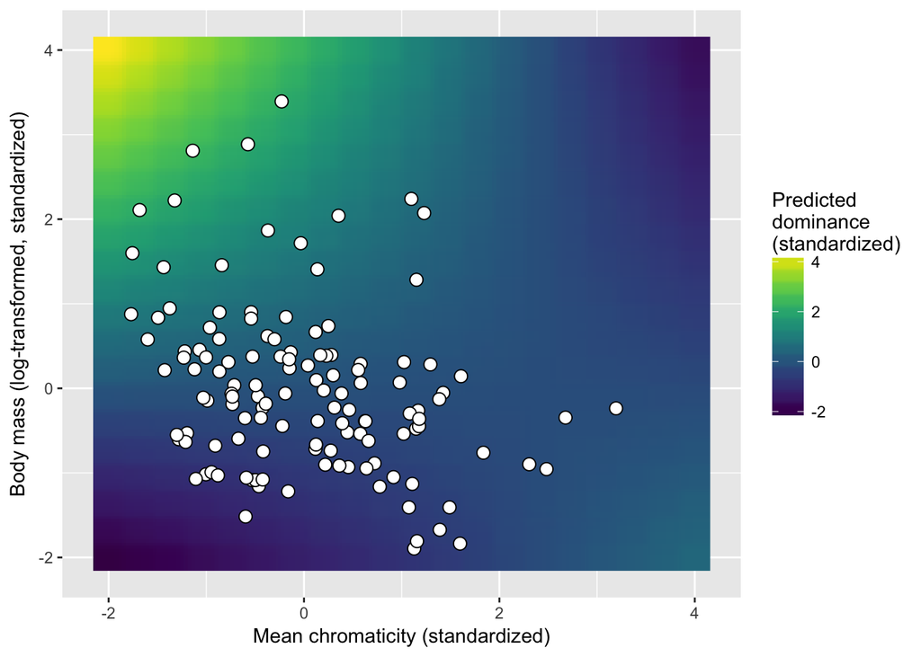

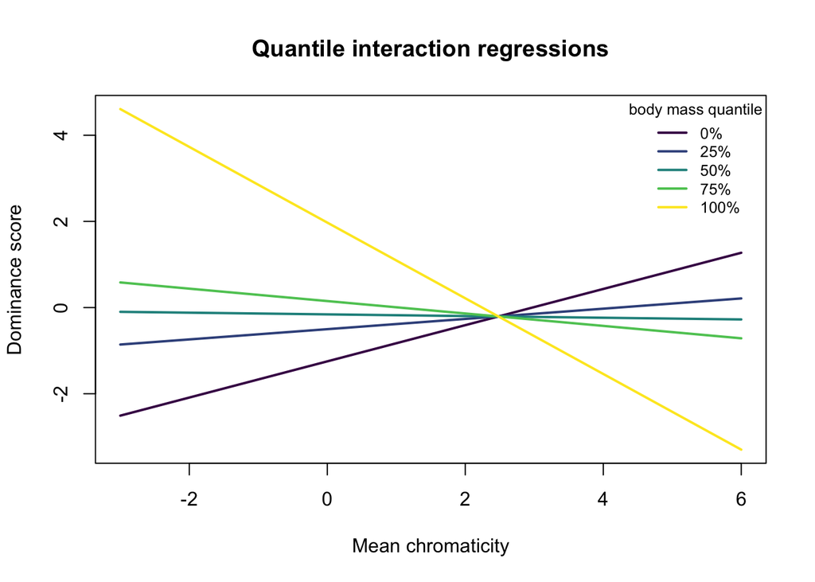

So for large body sizes, chromaticity is negatively associated with dominance, whereas for small birds this relationship is inverted and chromaticity is positively associated with dominance. Marginal effect of chromaticity is close to zero on average body sizes, though.

### Caveats

- could this interaction just be a byproduct of the lack of large and colorful birds? There is no significant relationship between body size and chromaticity, but nonetheless that upper right quadrant is empty.
- is this interaction only relevant outside the range of the data, or for extreme values of the range of the data?
- any other aspects of color I should consider?